# COSC-523: Lab 07

**Daniel Carter**

[Notebook Link](https://colab.research.google.com/drive/161Mp0Ag58nX4gA-KYYtAlqFlk4Wf-swK#scrollTo=1HW_tpnTHbiQ)

## Getting Started

Follow the instructions below to copy this notebook and to perform some initial setup.

1. Copy this notebook by selecting `File > Save a copy in Drive`.
2. A new window should open for the copied notebook. Move the new notebook to your course folder in Google Drive by selecting `File > Move` and then selecting the desired folder.
3. Update the name of the notebook by removing "Copy of" and replacing "Username" with your actual username.
4. Update the first cell in the notebook by specifying your course number (423 or 523) and by replacing "**Student Name**" with your actual name.
5. Do not edit the line that says `PLACEHOLDER_FOR_NOTEBOOK_LINK`. This will be used by the [Notebook Renderer](https://colab.research.google.com/drive/1CJTipys46ldZxJFwnt7XbdjQUfkmoXeU?usp=sharing) tool to insert a link to your Colab notebook.
6. Enable link sharing for your notebook.

# Part 1: Understanding the Fundamentals of YOLO Models

Instructions:

Answer the following questions to understand the basic concepts behind YOLO (You Only Look Once) models:

1. What is YOLO and how does it work?
2. Explain what the YOLO model is and how it differs from traditional object detection methods.
3. What is the structure of YOLO architecture?
4. Describe the general architecture of a YOLO model, including the role of convolutional layers, grid cells, and bounding boxes.
5. What are the advantages of YOLO compared to other object detection models like R-CNN or SSD?
6. Discuss the advantages and trade-offs of using YOLO for object detection, such as speed, accuracy, and real-time performance.
7. What is meant by "Anchor Boxes" in YOLO?
8. Explain how anchor boxes are used in YOLO for predicting bounding boxes and how they improve detection performance.
9. What is Non-Maximum Suppression (NMS) and why is it important in YOLO?
10. Describe the concept of Non-Maximum Suppression and its role in filtering out redundant predictions in object detection.
1. YOLO (You Only Look Once) is a system that quickly detects objects in images by scanning them once with a neural network. It splits the image into a grid, predicts objects in each section, and gives their locations and types at the same time.
2. YOLO is a fast object detection model that finds objects in one go, unlike older methods like R-CNN that first suggest possible object areas and then classify them. This makes YOLO quicker but sometimes less precise for complex images.
3. YOLO uses a neural network to pull out image features, then divides the image into a grid to predict object locations and types. It processes the image through layers to make these predictions all at once.
4. YOLO’s structure has a network that extracts image details, splits the image into grid cells, and predicts object locations (bounding boxes) and types for each cell. Each cell handles objects in its area, using boxes to pinpoint them.
5. YOLO is much faster, making it great for real-time uses like self-driving cars.
6. YOLO is super fast, perfect for real-time tasks, but it can miss small or crowded objects. Slower models might catch more details but take longer.
7. Anchor boxes are preset box shapes in YOLO that help predict where objects are. They make it easier for the model to fit objects of different sizes.
8. Anchor boxes give YOLO starting shapes to guess object locations, adjusting them to match different object sizes. This helps the model better locate and identify objects.
9. NMS is a cleanup step in YOLO that picks the best object prediction and removes extra, overlapping ones. It’s key to avoiding repeated detections and keeping results clear.
10. NMS chooses the strongest object prediction and removes others that overlap too much, based on how much they cover each other. In YOLO, it ensures only the best predictions stay, making the output cleaner.

# Part 2: Implementing YOLOv8 for Object Detection on a Custom Image

Instructions:

1. Import the necessary libraries for Object Detection with YOLO
2. Load the image Lab 7 Part 2.jpg and instantiate 2 YOLO models: "yolov8n.pt" and "yolov8x.pt"
3. Perform object detection the image one by one by using the 2 different models
4. Draw bounding boxes around detected objects in each image and display both images side by side
5. Display the images with the predicted bounding boxes and class labels.
6. Which model did better? Why?

```python
# Install dependencies
!pip install ultralytics opencv-python-headless
```

```python
import cv2
from ultralytics import YOLO
from google.colab import files
import os
import matplotlib.pyplot as plt
import numpy as np
```

```python
#model 1
model1 = YOLO('yolov8n.pt')

#model 2
model2 = YOLO('yolov8x.pt')

image = files.upload()

filename, image_bytes = list(image.items())[0]
with open(filename, 'wb') as f:
  f.write(image_bytes)

results1 = model1(filename)
results2 = model2(filename)
```

Upload widget is only available when the cell has been executed in the current browser session. Please rerun this cell to enable.

```
Saving Lab 7 part 2.jpg to Lab 7 part 2 (3).jpg

image 1/1 /content/Lab 7 part 2 (3).jpg: 448x640 4 persons, 1 car, 1 truck, 1 dog, 54.8ms
Speed: 6.9ms preprocess, 54.8ms inference, 159.3ms postprocess per image at shape (1, 3, 448, 640)

image 1/1 /content/Lab 7 part 2 (3).jpg: 448x640 5 persons, 1 car, 1 dog, 52.0ms
Speed: 2.2ms preprocess, 52.0ms inference, 1.7ms postprocess per image at shape (1, 3, 448, 640)
```

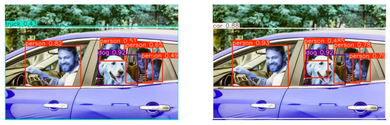

```python
#visualize the results side by side
fig, axes = plt.subplots(1, 2, figsize=(10,10)) # Create a figure with 1 row and 2 columns
#first results
axes[0].imshow(results1[0].plot()) # Plot on the first subplot
axes[0].axis('off')
#second results
axes[1].imshow(results2[0].plot()) # Plot on the second subplot
axes[1].axis('off')
plt.show()
```

# Results

## The second model did much better. This is because it was a bigger version of the YOLO model so it was more accurate than the smaller version we used in the first model

# Part 3: Analyzing YOLO predictions

Instructions:

1. Use results[0].names to store the class names in a dictionary named: dict_classes
2. Use results[0].boxes.cls to store the class indexes from both models in separate numpy arrays called array1 and array2 (results1[0].boxes.cls actually is of type tensor, you will need to convert it to numpy). If you used a GPU in your session, you will need to use: results[0].boxes.cls.cpu()
3. Now you need to create and populate 2 lists called class_names1_list and class_names2_list. These lists should include the predicted names of classes (not the indexes) as predicted by model 1 and model 2 in the last part. For this, you will need to run a for loop through array1 or array2 and then for each iteration extract the current values of array1 and array2 and use it to populate the lists class_names1_list and class_names2_list. Remember that dict_classes contains the correct mapping of number to class.
4. Print both the lists
5. For how many items were both models in agreement? Write the code for it.

```python
#store class names in dictionary
dict_classes = results1[0].names

array1 = results1[0].boxes.cls.cpu().numpy()
array2 = results2[0].boxes.cls.cpu().numpy()

class_names1 = []
class_names2 = []
for idx1,idx2 in zip(array1,array2):
  class_names1.append(dict_classes[int(idx1)])
  class_names2.append(dict_classes[int(idx2)])

#print the lists
print('Class names predicted by model 1: ', class_names1)
print('Class names predicted by model 2: ', class_names2)

#How many items were in both
agreements = sum(1 for name1, name2 in zip(class_names1, class_names2) if name1 == name2)
print(f'Number of items in were both models were in agreement: {agreements} items')
```

```
Class names predicted by model 1:  ['dog', 'person', 'person', 'person', 'person', 'truck', 'car']
Class names predicted by model 2:  ['person', 'dog', 'car', 'person', 'person', 'person', 'person']
Number of items in were both models were in agreement: 2 items
```

# Part 4: Adjusting YOLO output based on a threshold

Instructions:

In this exercise we will learn how to only predict classes that cross a certain confidence theshold. Here are the steps

1. Lokk at the code you used in Part 1. Instead of using 2 models, we will only use 1 model: yolov8n.pt. Apply the model and store the output in results
2. Now set a threshold by setting a variable: confidence_threshold to 0.5
3. We will now filter the bounding boxes detected by YOLOv8 based on a confidence score threshold. We will only keep the boxes that have a confidence score greater than or equal to a specified threshold. Initialize an empty list called filtered_boxes.
4. Loop through all detected bounding boxes:(hint: you will need to go through results[0].boxes.conf)
5. Check if the confidence score meets the threshold:For each bounding box, the confidence score is accessed using results[0].boxes.conf[current index]
6. If this condition is met (i.e., the confidence score is high enough),add the index of the bounding box to the filtered_boxes list
7. The rest of the code is given to you, however you need to make one modifcation. If you completed all the steps correctly, then you will see class indexes with each bounding box. Modify the code given to you so you actually see the class names and not the class index next to the bounding box.

Upload widget is only available when the cell has been executed in the current browser session. Please rerun this cell to enable.

```
Saving Lab 7 part 2.jpg to Lab 7 part 2 (4).jpg

image 1/1 /content/Lab 7 part 2 (4).jpg: 448x640 4 persons, 1 car, 1 truck, 1 dog, 8.4ms
Speed: 2.3ms preprocess, 8.4ms inference, 1.7ms postprocess per image at shape (1, 3, 448, 640)
```

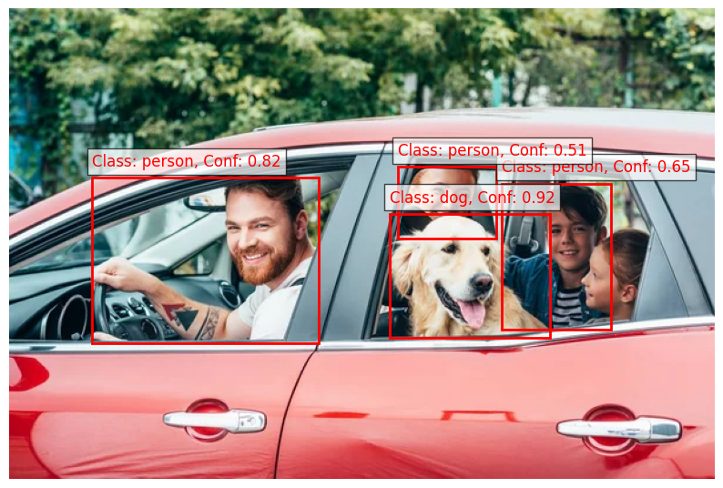

```python
# Upload the image from your computer
uploaded = files.upload()

# image filename
filename, image_bytes = list(uploaded.items())[0]
with open(filename, 'wb') as f:
  f.write(image_bytes)

# Read the image with OpenCV
image = cv2.imread(filename)

# Convert the image from BGR to RGB (since OpenCV loads images in BGR by default)
image_rgb = cv2.cvtColor(image, cv2.COLOR_BGR2RGB)

# Load the YOLOv8 model (YOLOv8n is the smallest version)
model = YOLO('yolov8n.pt')

# Perform object detection on the image
results = model(filename)

# Set the confidence threshold
confidence_threshold = 0.5

# Initialize an empty list to store the filtered bounding box indices
filtered_boxes = []

# Filter out boxes with confidence scores below the threshold
for i in range(len(results[0].boxes.conf)):
    confidence = results[0].boxes.conf[i]
    if confidence >= confidence_threshold:
        filtered_boxes.append(i)

# Get the filtered boxes (coordinates, confidence scores, etc.)
filtered_boxes_obj = results[0].boxes[filtered_boxes]
filtered_confidences = results[0].boxes.conf[filtered_boxes]  # Confidence scores for filtered boxes
filtered_classes = results[0].boxes.cls[filtered_boxes]  # Class indices for filtered boxes
filtered_class_names = [results[0].names[int(cls)] for cls in filtered_classes]  # Class names for filtered boxes

# Load the image
plt.figure(figsize=(10, 10))
plt.imshow(image_rgb)
plt.axis('off')

# Plot the bounding boxes and add class labels and confidence scores
for i, box in enumerate(filtered_boxes_obj):
    x1, y1, x2, y2 = box.xyxy[0].cpu().numpy()  # Get box coordinates
    class_id = (filtered_class_names[i])  # Get class ID
    confidence = filtered_confidences[i]  # Get confidence score

    # Draw the bounding box
    plt.gca().add_patch(plt.Rectangle((x1, y1), x2 - x1, y2 - y1, linewidth=2, edgecolor='r', facecolor='none'))

    # Display class and confidence score above the bounding box
    label = f"Class: {class_id}, Conf: {confidence:.2f}"
    plt.text(x1, y1 - 10, label, color='r', fontsize=12, bbox=dict(facecolor='white', alpha=0.7))

plt.show()
```

# Part 5: Running YOLO on Video

Instructions:

1. Choose a video of your choice and apply 3 different YOLO models of your choosing to perform object detection on it.
2. Upload the output video for all 3 models
3. Explain why you chose your specific models
4. Which model did the best? Why?

```python
#mount drive
from google.colab import drive
drive.mount('/content/drive')
```

```python
#path to video
video_path = '/content/drive/MyDrive/cass_playing_with_dogs.mp4'

#open the video
cap = cv2.VideoCapture(video_path)

#validate video works
if not cap.isOpened():
    print("Error opening video file")
    exit()

frame_width = int(cap.get(cv2.CAP_PROP_FRAME_WIDTH))
frame_height = int(cap.get(cv2.CAP_PROP_FRAME_HEIGHT))
fps = int(cap.get(cv2.CAP_PROP_FPS))

# Load the models
model1 = YOLO('yolov8n.pt')
model2 = YOLO('yolov8s.pt')
model3 = YOLO('yolov8x.pt')

# Define new output video for each model *before* the loop
fourcc = cv2.VideoWriter_fourcc(*'mp4v')
output_video1 = cv2.VideoWriter('output_video_model_yolov8n.mp4', fourcc, fps, (frame_width, frame_height))
output_video2 = cv2.VideoWriter('output_video_model_yolov8s.mp4', fourcc, fps, (frame_width, frame_height))
output_video3 = cv2.VideoWriter('output_video_model_yolov8x.mp4', fourcc, fps, (frame_width, frame_height))

#frame count
frame_count = int(cap.get(cv2.CAP_PROP_FRAME_COUNT))
print(f'Processing {frame_count} frames')

while True:
    ret, frame = cap.read()
    if not ret:
        print('End of video')
        break

    # Create a copy of the original frame for each model's processing
    frame1 = frame.copy()
    frame2 = frame.copy()
    frame3 = frame.copy()

    result1 = model1(frame1)
    result2 = model2(frame2)
    result3 = model3(frame3)

    #draw bounding boxes on each output
    for result in result1:
        for box in result.boxes:
            x1, y1, x2, y2 = map(int, box.xyxy[0].cpu().numpy())
            conf = box.conf[0]
            cls = int(box.cls[0])
            label = f'{model1.names[cls]} {conf:.2f}'
            cv2.rectangle(frame1, (x1, y1), (x2, y2), (0, 255, 0), 2)
            cv2.putText(frame1, label, (x1, y1 - 10), cv2.FONT_HERSHEY_SIMPLEX, 0.5, (0, 255, 0), 2)

    for result in result2:
        for box in result.boxes:
            x1, y1, x2, y2 = map(int, box.xyxy[0].cpu().numpy())
            conf = box.conf[0]
            cls = int(box.cls[0])
            label = f'{model2.names[cls]} {conf:.2f}'
            cv2.rectangle(frame2, (x1, y1), (x2, y2), (0, 255, 0), 2)
            cv2.putText(frame2, label, (x1, y1 - 10), cv2.FONT_HERSHEY_SIMPLEX, 0.5, (0, 255, 0), 2)

    for result in result3:
        for box in result.boxes:
            x1, y1, x2, y2 = map(int, box.xyxy[0].cpu().numpy())
            conf = box.conf[0]
            cls = int(box.cls[0])
            label = f'{model3.names[cls]} {conf:.2f}'
            cv2.rectangle(frame3, (x1, y1), (x2, y2), (0, 255, 0), 2)
            cv2.putText(frame3, label, (x1, y1 - 10), cv2.FONT_HERSHEY_SIMPLEX, 0.5, (0, 255, 0), 2)
    #Write the frames
    output_video1.write(frame1)
    output_video2.write(frame2)
    output_video3.write(frame3)

cap.release()
output_video1.release()
output_video2.release()
output_video3.release()
cv2.destroyAllWindows()
```

```
Downloading https://github.com/ultralytics/assets/releases/download/v8.3.0/yolov8s.pt to 'yolov8s.pt'...
```

[output not shown]

[output cut: 4946 more lines]

[output not shown]

```python
#Download each video
files.download('output_video_model_yolov8n.mp4')
files.download('output_video_model_yolov8s.mp4')
files.download('output_video_model_yolov8x.mp4')
```

# The best model is the last one that we used yolov8x. From watching all three videos, the labels were the most accurate

# Submission Instructions

1. Perform a Restart and Run All by clicking **Tools > Restart session and run all**.
2. Copy the link to your notebook by clicking **Share > Copy Link**.
3. Paste the copied link into the `notebook_url` field in the [Notebook Renderer](https://colab.research.google.com/drive/1CJTipys46ldZxJFwnt7XbdjQUfkmoXeU?usp=sharing) tool and then execute the cell to render the notebook.
4. The Notebook Renderer will open up a save file dialog. Save the resulting HTML file yo your local machine.
5. Submit the HTML file to Canvas.